# Exploring the BRFSS data

## Setup

### Load packages

```r
library(ggplot2)
library(dplyr)
library(corrplot)
```

### Load data

```r
load("brfss2013.RData")
```

## Part 1: Data

The original data set analyzed in this project includes factors assessed by the BRFSS in 2013, with 491775 observations of 330 variables. I am interested in the following variables:

- genhlth: General Health.
- X_age_g: Six-level imputed age category.
- X_state: Record state.
- sex: Sex of respondent.
- sleptim1: Average Daily hours of sleep
- income2: Annual household income from all sources
- avedrnk2: Avg alcoholic drinks per day in past 30
- smokday2: Do you now smoke cigarettes every day, some days, or not at all?

## Part 2: Research questions

**Research quesion 1:** As a first question, I am interested in obtain some summary statistics of general health status (‘genhlth’) ,like `mean`, `median`, `sd`, `IQR`, `min`, and `max` and top 5 states with high health status.

**Research quesion 2:** In the second question, I am interested in exploring the correlation between people’s sleep time, age and incomes.

**Research quesion 3:** Following with the previous questions, I am interested in exploring correlations between selected variables, like health condition, like income, age, sleeptime, cholesterol awareness, Smoke days and so on.

## Part 3: Exploratory data analysis

**Research quesion 1:** As a first question, I am interested in obtain some summary statistics of general health status (‘genhlth’) ,like `mean`, `median`, `sd`, `IQR`, `min`, and `max` and top 5 states with high health status.

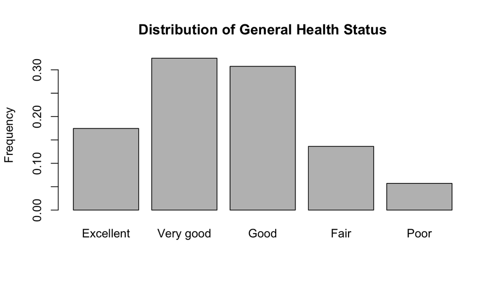

```r
barplot(prop.table(table(brfss2013$genhlth)), ylab = "Frequency", main = "Distribution of General Health Status")
```

```r
#delete the NA items
brfssnew <- subset(brfss2013, (!is.na(brfss2013$genhlth)))

#transfer the categorical variables into numeric variables
brfssnew$genhlth1[brfssnew$genhlth == "Excellent"] <- "1"
brfssnew$genhlth1[brfssnew$genhlth == "Very good"] <- "2"
brfssnew$genhlth1[brfssnew$genhlth == "Good"] <- "3"
brfssnew$genhlth1[brfssnew$genhlth == "Fair"] <- "4"
brfssnew$genhlth1[brfssnew$genhlth == "Poor"] <- "5"

#summary statistics of general health status
brfssnew$genhlth1 <- as.numeric(factor(brfssnew$genhlth1))
brfssnew %>%
  summarise(mu = mean(genhlth1), pop_med = median(genhlth1),
  sigma = sd(genhlth1), pop_iqr = IQR(genhlth1),
  pop_min = min(genhlth1), pop_max = max(genhlth1),
  pop_q1 = quantile(genhlth1, 0.25),  # first quartile, 25th percentile
  pop_q3 = quantile(genhlth1, 0.75))  # third quartile, 75th percentile
```

```
##         mu pop_med    sigma pop_iqr pop_min pop_max pop_q1 pop_q3
## 1 2.576529       3 1.099124       1       1       5      2      3
```

```r
#top 5 states with high health status
brfssnew %>%
  group_by(X_state) %>%
  summarise(mean_state = mean(genhlth1)) %>%
  arrange(desc(mean_state))
```

```
## # A tibble: 53 × 2
##          X_state mean_state
##           <fctr>      <dbl>
## 1    Puerto Rico   3.011521
## 2    Mississippi   2.883486
## 3        Alabama   2.862128
## 4       Arkansas   2.857906
## 5  West Virginia   2.852506
## 6       Kentucky   2.834147
## 7      Louisiana   2.827765
## 8      Tennessee   2.827658
## 9       Oklahoma   2.730985
## 10      Missouri   2.699845
## # ... with 43 more rows
```

**Research quesion 2:** In the second question, I am interested in exploring the correlation between people’s sleep time, age and incomes.

- Senior people seem to have more average hours of sleep.
- Average sleeping hours for people with high incomes are mostly in the range of 6-8 hours, while for people with low incomes, the ranges are larger.
- Highest incomes (>75,000) mostly appear in people from age 35 -54.

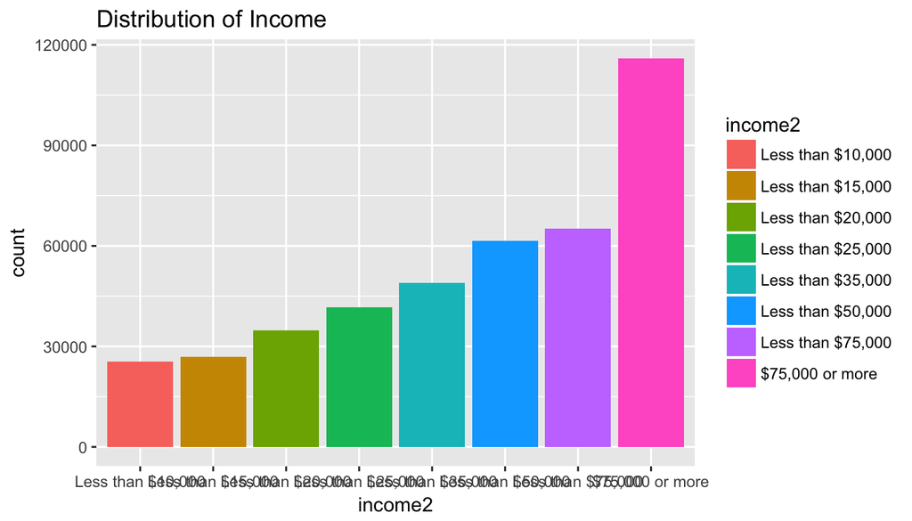

```r
age.income <- select(brfss2013, X_age_g, sex, income2) %>%
  filter(!is.na(X_age_g), !is.na(sex), !is.na(income2))

ggplot(data = age.income) +
  geom_bar(mapping = aes(x = income2, fill = income2))+
  ggtitle('Distribution of Income')
```

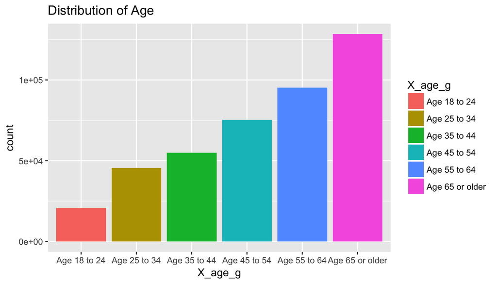

```r
ggplot(data = age.income) +
  geom_bar(mapping = aes(x = X_age_g, fill = X_age_g))+
  ggtitle('Distribution of Age')
```

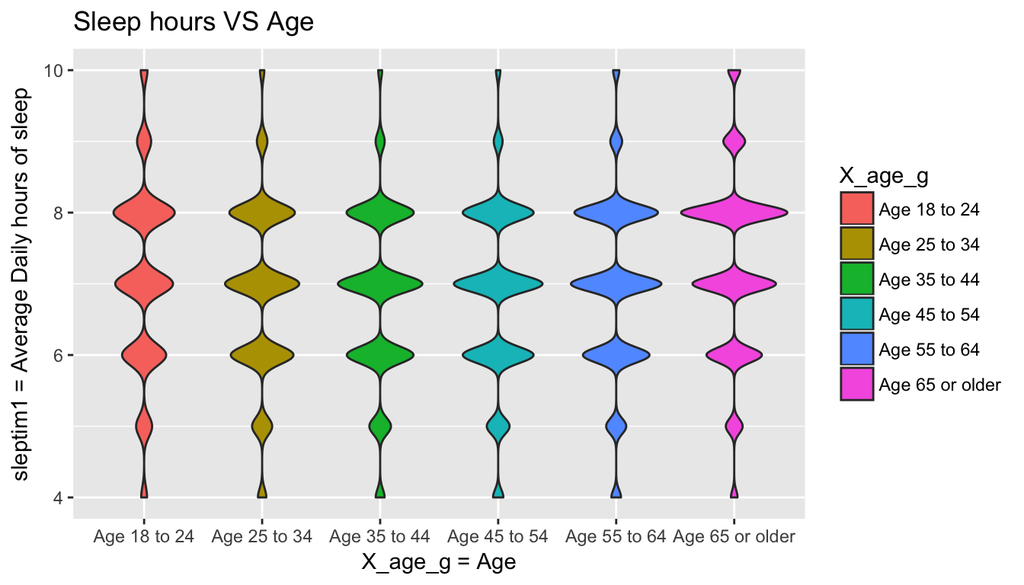

```r
sleep.age<- select(brfss2013, X_age_g,  sleptim1) %>%
  filter(!is.na(X_age_g), !is.na(sleptim1), sleptim1 <= 10,sleptim1>=4)

ggplot(data = sleep.age, aes (x = X_age_g, y = sleptim1)) +
  geom_violin(aes(fill = X_age_g)) +
  xlab("X_age_g = Age") + ylab ("sleptim1 = Average Daily hours of sleep")+
  ggtitle('Sleep hours VS Age')
```

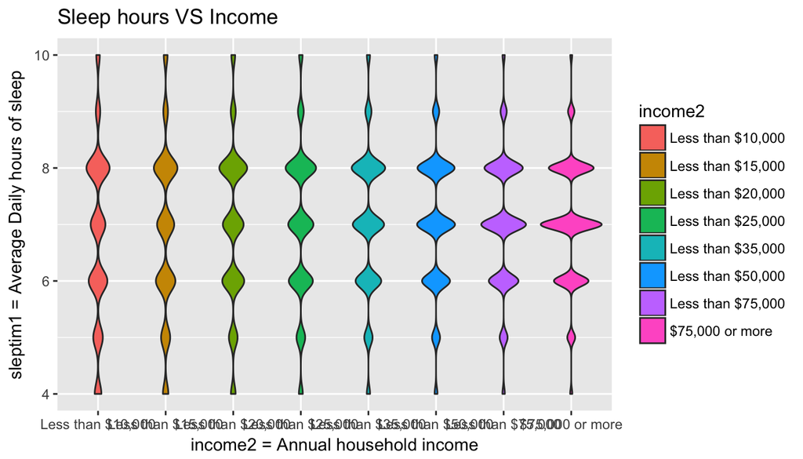

```r
sleep.income <- select(brfss2013, sleptim1, sex, income2) %>%
  filter(!is.na(sleptim1), !is.na(sex), !is.na(income2), sleptim1 <= 10, sleptim1>=4)
ggplot(data = sleep.income, aes(x = income2, y = sleptim1)) +
  geom_violin(aes(fill = income2))+
  xlab("income2 = Annual household income") +
  ylab ("sleptim1 = Average Daily hours of sleep") +
  ggtitle('Sleep hours VS Income')
```

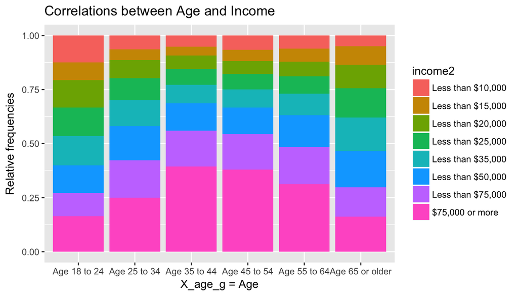

```r
ggplot(data = age.income) +
  geom_bar(mapping = aes(x = X_age_g, fill = income2), position = "fill")+
  xlab("X_age_g = Age") +
  ylab ("Relative frequencies")+
  ggtitle('Correlations between Age and Income')
```

**Research quesion 3:** Following with the previous questions, I am interested in exploring correlations between selected variables, like health condition, like income, age, sleeptime, cholesterol awareness, Smoke days and so on.

To calculate the correaltions, the category values are transfered to numerical values based on following rules:

- genhlth: excellent to Poor -> 1-5
- X_age_g: 18 to 65 -> 1-6
- Sex: M/F -> 1/2
- Income: 10,000 to 75,000 -> 1-8
- smokday2: every day, some days, Not at all -> 1,2,3

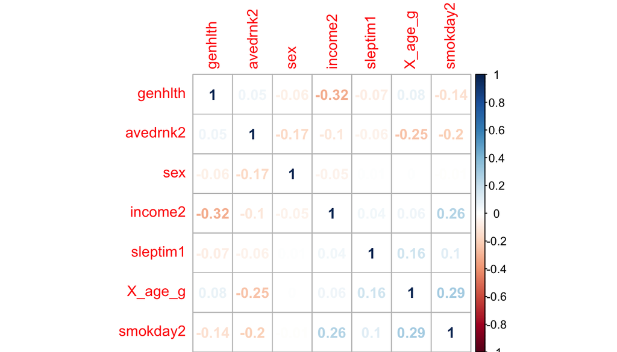

```r
select.data <- select(brfss2013, genhlth, X_age_g, sex, income2, sleptim1, avedrnk2, smokday2)
select.data <- select.data[complete.cases(select.data),] #delete NA
select.data <- sapply(select.data,as.numeric)
matrix.cor <- cor(select.data)
corrplot(matrix.cor, order ="hclust",method = "number")
```